# NYU SURP 2019 R course Class 10: Summarizing data

Eugene Plavskin

Grace Avecilla

Tobi Shraink

07/25/2019

# Review

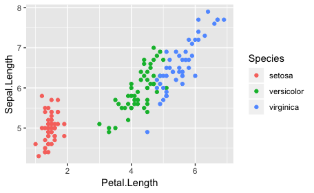

# ggplot continued

## Boxplots

We can use ggplot to make other kinds of plots too.

Imagine we wanted to make a boxplot of our Sepal Length by species in our iris data. What would be on the x axis? What would be on the y axis? *DISCUSS* with your partners.

What `geom` command would we use to make a boxplot in ggplot? (Google it!)

Try writing some code to make a ggplot boxplot of Sepal Length by species below.

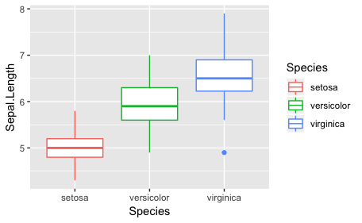

```r
# ggplot to make a boxplot of Sepal Length for each species
ggplot(iris_df, aes(y = Sepal.Length, x = Species, color = Species)) +
  geom_boxplot()
```

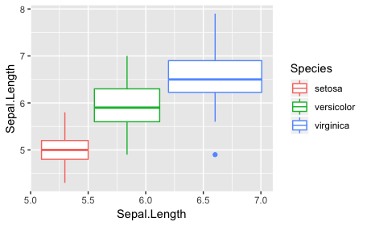

```r
ggplot(iris_df, aes(x = Sepal.Length, y = Sepal.Length, color = Species, shape = Species)) +
  geom_boxplot()
```

## Combining plots

One of the best things about ggplot is that it makes layering different kinds of data representations really easy. Boxplots are great because they show the general trends of your data (mean or median, and how far your data extends); however, looking at the actual datapoints can be incredibly important as well, since they can sometimes tell a story obscured by dumping them all into a boxplot. That’s why it’s become popular to show *both* summary statistics (e.g. a boxplot, or even just a line representing the mean) *and* your individual datapoints on the same plot.

You know how to set up the ‘structure’ of you iris data in ggplot. You know how to get ggplot to display that data as a boxplot, or as individual points, using `geom_`. Try to combine two geoms to get both a boxplot of the sepal length and, overlaid onto it, the individual data points for each plant of that species.

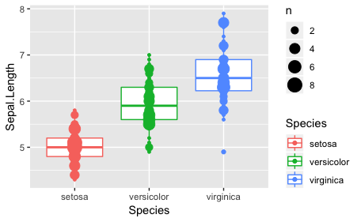

# Subsetting data

Try this on your own. Create a data frame of all the plants where sepal width is greater than 3.5.

# Getting useful info about your data

It can be incredibly helpful to quickly get summary info for your data in an accessible, R-readable format. We’ve already calculated some ‘summary statistics’ (`mean`) for every column, and we saw how ggplot easily lets us split our plot up by categories (*eg* through using different colors for each one). Now let’s do the same with summary statistics.

## Using the summary function

A really useful function for quickly learning about the properties of your data is `summary()`. It shows you the mean, median, and quantiles of your numeric data, as well as counts for each data category. Try this:

```r
iris_summary <- summary(iris_df)
print(iris_summary)
```

[output not shown]

One reason `summary()` is often not particularly useful is that it summarizes *all* the data in your dataframe. Notice that it’s not splitting the summaries by species, which is probably what we would want to happen.

One way to get around this is through subsetting. Make a subset of the iris data that only contains data for the *setosa* species, and then run the `summary` function on this subset.

```r
# use subset() to make a dataframe, setosa_df, that contains only the data where
# Species is setosa
# (hint: you want the Species column to equal 'setosa')

# pass the summary data for setosa_df into a new variable called setosa_summary

# print out setosa_summary
```

There are a couple of important limitations to the approach we just used. First of all, we have to do this to one category at a time. This may not be so bad for 3 species, but imagine we had a dataset containing 50 species (or other categories we were interested in). Second, if you look in your **Environment** window, you’ll notice that neither iris_summary or setosa_summary are dataframes. The `summary` function produces a weird R data type called a *table*, which is easy to look at but a pain to do anything with.

```r
View(iris_summary)
```

For example, if you wanted to plot the results of the summary functions for a bunch of species using ggplot, it would be a very big pain to do.

# Aggregating data

Of course, if you want to summarize complicated data in a compact, readable, graphable way, R has a great function for that! In fact, there are actually a whole bunch of ways to do this, but the one we have time to go into is `aggregate()`. There are also a few different ways to use `aggregate`, but the basic one is this: give it which *data* to work with (a dataframe), what column you want it to summarize, a category (or multiple categories) to group things by (*~*), and a function (*FUN*) you want it to run on the data in each category.

```r
iris_means <- aggregate(iris_df, Petal.Width ~ Species, FUN = mean)
```

```
Error in aggregate.data.frame(iris_df, Petal.Width ~ Species, FUN = mean) :
  'by' must be a list
```

We can also try aggregating by more than one category! Imagine we have a ‘Flower.Color’ column for these irises.

We can now aggregate by two properties at once!

```r
iris_sepal_length_means_color <-
  aggregate(Sepal.Length ~ Species + Flower.Color, data = iris_df, FUN = mean)
```